# Camera trapping and telemetry for detecting and quantifying animal interactions: Not anything goes - ScienceDirect

## [Ecological Indicators](https://www.sciencedirect.com/journal/ecological-indicators)

[Volume 160](https://www.sciencedirect.com/journal/ecological-indicators/vol/160/suppl/C), March 2024, 111877

# Camera trapping and telemetry for detecting and quantifying animal interactions: Not anything goes

https://doi.org/10.1016/j.ecolind.2024.111877[Get rights and content](https://s100.copyright.com/AppDispatchServlet?publisherName=ELS&contentID=S1470160X24003340&orderBeanReset=true)

Under a Creative Commons [license](http://creativecommons.org/licenses/by/4.0/)

open access

## Highlights

- •

  Camera Trapping Resource Monitoring shows high ability to detect animal interactions.
- •

  Environment and species ecology limit the feasibility of Resource Monitoring.
- •

  Regular Grid Camera Trapping is able to identify which species are interacting.
- •

  Quantification of interactions by Regular Grid Camera Trapping should be avoided.
- •

  [Telemetry](https://www.sciencedirect.com/topics/agricultural-and-biological-sciences/telemetry) at high fixation rates shows great performance in detecting interactions.

## Abstract

Telemetry using Global Positioning Systems (GPS) and camera trapping are two widely used approaches to detect animal interactions involving wildlife. However, while the former follows an individual-based approach, the latter follows a population-based approach, which may lead to different outcomes when describing interaction networks. In this study, we compared the performance of GPS telemetry, regular grid camera trapping (CT-RG), and resource monitoring camera trapping (in which cameras are placed monitoring a valuable resource for animals, such as water or food; CT-RM) in detecting and quantifying animal interactions. We used spatially explicit simulated trajectories of 150 individuals of 3 imaginary species. We simulated 9 different scenarios of resource visiting frequency and spatial resource aggregation in the environment to assess the potential influence of animal behavior and landscape structure. The simulated trajectories were sampled using the three approaches with six different sampling efforts each, and the direct and indirect interactions between the three species were quantified. Additionally, CT-RG and CT-RM were applied in Doñana National Park to evaluate their differences and limitations in field application. In terms of simulation, CT-RM offered the best performance in detecting direct interactions, and GPS achieved good performance when using a high number of fixes per hour. Both CT-RM and GPS also achieved good performance in detecting indirect interactions. CT-RG, on the other hand, missed most direct and indirect interactions, but correctly identified the pairs of species that interacted indirectly at some point. In the field trial, CT-RM and CT-RG detected almost the same number of species pairs interacting indirectly. However, CT-RG missed at least half of the species pairs that interacted directly. The spatial aggregation of the resource favors the performance of GPS over CT-RM, while the opposite occurs when the frequency of animal visits to the resource increases. To summarize, CT-RM is the most reliable method for detecting interactions when resource monitoring is feasible (e.g., small ponds in arid areas). Otherwise, GPS may show better performance, although it may miss direct interactions if a high fix rate is not used. Finally, the use of CT-RG should be limited to identify which species could potentially interact indirectly, but not to quantify these interactions.

## Graphical abstract

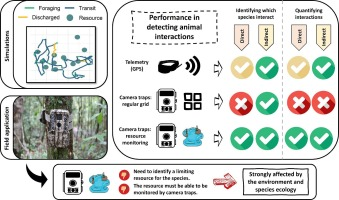

## Keywords

Camera trapping

Contact networks

Disease transmission

GPS

Telemetry

Wildlife interactions

## 1. Introduction

The study of spatial interactions between wild animals and with [livestock](https://www.sciencedirect.com/topics/agricultural-and-biological-sciences/farm-animal) is of great importance for ecological (such as predation, reproduction, social relationships, or group dynamics; Latham et al., 2011, Mejia Salazar et al., 2016, Spiegel et al., 2020), and epidemiological purposes, as they can involve pathogen transmission (Bacigalupo et al., 2020). From the epidemiological point of view, we can differentiate direct interactions, which involve proximate contact between individuals, and indirect interactions, where transmission may be mediated by the environment and/or a vector (Craft, 2015). The study of interactions is crucial to identify which species may be involved in the spatio-temporal dynamics of pathogens, as well as their relevance (Ferreira et al., 2023, Manlove et al., 2022).

The methodologies used to study interactions involving wildlife are typically individual-based, following a Lagrangian perspective, in which the sampling device moves with the individual (Triguero-Ocaña et al., 2021). Individual-level obtained information can be scaled up to population-level patterns to answer ecological and epidemiological questions (Mueller and Fagan, 2008, Phillips et al., 2019). Global Positioning Systems telemetry (GPS) and/or proximity loggers are the survey approaches most frequently used for epidemiological purposes, although the latter is mostly limited to the detection of direct interactions (Drewe et al., 2012, Triguero-Ocaña et al., 2019). These methodologies require capturing individuals, which implies invasiveness, [animal welfare](https://www.sciencedirect.com/topics/agricultural-and-biological-sciences/animal-welfare) issues, and costly and time-consuming procedures (Shimada et al., 2020), being especially constrained when working with endangered, small and/or elusive species (He et al., 2022). Camera trapping, on the other hand, is a population-based sampling approach that follows a Eulerian perspective, i.e., the sampling devices are in a fixed location where animals may occur eventually (Bassing et al., 2023, Phillips et al., 2019). Its use in wildlife monitoring has increased over the recent years, primarily because it is a mostly noninvasive procedure and its ability to detect elusive species (Delisle et al., 2021). Camera trapping has been used mainly in ecological studies, such as behavior, activity patterns, habitat selection and use, territory occupancy, scavenging, or competition for resources, among others (Burton et al., 2015). Camera trapping has also been used for the detection of interactions between animals for ecological purposes, such as group or predator–prey relationships, as well as [epidemiological studies](https://www.sciencedirect.com/topics/agricultural-and-biological-sciences/epidemiological-study), such as interactions between wildlife and livestock (Kukielka et al., 2013, Niedballa et al., 2019, Smith et al., 2020). Most studies focused on epidemiological interests usually place [camera traps](https://www.sciencedirect.com/topics/agricultural-and-biological-sciences/camera-trap) in locations where the occurrence of an interaction is deemed most probable or where it can be detected (camera trapping for resource monitoring; CT-RM), such as in feeding or watering points, as well as probable entry zones to a farm (Bacigalupo et al., 2022, Kukielka et al., 2013, Payne et al., 2016, Varela-Castro et al., 2021). The increasing use of camera trapping, coupled with citizen science, is also leading to large-scale datasets encompassing a wide variety of species and locations (Green et al., 2022, Hsing et al., 2022). However, camera trapping sampling designs often require a random deployment of cameras within the study area (see e.g., Rowcliffe et al., 2008), for instance, based on regular grid pattern (CT-RG; Rowcliffe et al., 2008). The amount of information generated by CT-RG has led to its use also for the detection and quantification of animal interactions for epidemiological purposes (Barroso et al., 2023, Triguero-Ocaña et al., 2020;b).

Recent comparative studies of Lagrangian and Eulerian perspectives have shown that they yield different results when estimating different ecological parameters (Bassing et al., 2023, Ferrer-Ferrando et al., 2023). While GPS has been considered the reference methodology for calculating animal interactions, its performance has not yet been compared with CT-RM. Additionally, a proper evaluation remains unknown when comparing against CT-RG (Triguero-Ocaña et al., 2020b). These comparisons are challenging, as they require us to know the actual number of interactions between individuals. In this regard, spatially explicit simulations of animal trajectories are often used to test behavioral hypotheses of wildlife under controlled conditions (Gurarie et al., 2015, Palencia et al., 2021a). We used this simulation approach to evaluate the performance of these three approaches, GPS, CT-RG, and CT-RM, in the detection and quantification of interactions between pairs of species. Additionally, we evaluated how the [animal behavior](https://www.sciencedirect.com/topics/agricultural-and-biological-sciences/animal-behaviour) and the environment affect the performance of each approach. Finally, CT-RG and CT-RM were applied simultaneously for the quantification of interactions among wild mammals in the Doñana National Park (DNP) to verify whether the differences revealed between both approaches through simulation were also evident with real data, as well as to identify their limitations under field conditions.

## 2. Materials and methods

### 2.1. Performance evaluation using simulations

We used spatially explicit simulations of animal trajectories. In these simulations, we assumed that animals moved in an environment of 40 km<sup>2</sup> including 30 locations of a resource they needed to visit at a certain frequency, which could be interpreted as a water point or a feeding site, for example (Payne et al., 2016). In each step of the simulation, the animals move a distance given by a Gamma function and turn an angle given by a Cauchy distribution. The animals could exhibit three different behaviors for moving within a randomly shaped home range: slow and tortuous Brownian motion (associated with foraging), fast and less tortuous Brownian motion (associated with transit), or fast and directed movement toward the resource (associated with a discharged state, in which the animal needs to visit the resource to recharge). The need to visit the resource was controlled by a recharge-and-discharge model (Hooten et al., 2019), where the animal progressively discharges at each simulation step and recharges upon visiting the resource (see Fig. 1).

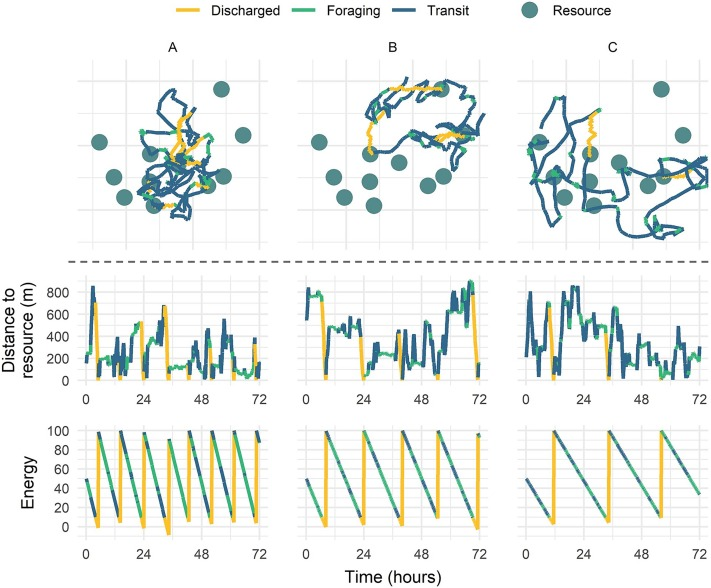

1. [Download: Download high-res image (617KB)](https://ars.els-cdn.com/content/image/1-s2.0-S1470160X24003340-gr1_lrg.jpg)
2. [Download: Download full-size image](https://ars.els-cdn.com/content/image/1-s2.0-S1470160X24003340-gr1.jpg)

Fig. 1. Example of simulation for the three species (A, B and C, from left to right) for 72 h. At the top, the trajectory followed. In the middle, the distance to the closest resource. At the bottom, the individual's energy. At each step, the individual loses some energy and has a certain probability of switching between the behaviors ‘foraging’ and ‘transit’. When its energy is close to depletion, it heads to the nearest resource to recharge.

We simulated three fictional species (A, B and C) with different home range sizes, movement speed, tortuosity, probability of behavior change, and resource needs for each one (see Table 1). These parameters can affect the proportion of interactions that occur at the resource compared to those that occur at a random location, and therefore, they can influence the performance of the approaches. Consequently, we simulated three scenarios with different charge and discharge parameters, providing variability to the number of daily visits of each species to the resource (see Table 2), thus accounting for variability in the proportion of interactions at the resource and outside. Furthermore, the spatial aggregation of the resource in the environment could also affect the performance of the respective approaches. Hence, we considered three scenarios of resource aggregation. In the lower aggregation scenario, the resource is evenly distributed (in a regular grid) in the environment, while in the higher aggregation scenario, it is concentrated in two areas (see Table 2). Overall, the experiment resulted in a total of nine scenarios. For each scenario, we simulated 150 animals (50 of each species) over a period of 30 days, at a time interval of 1 fix each 5 min.

Table 1. Parameters used to simulate the trajectories of the three species (A, B, and C). The Gamma function to determine the displacement distance at each step is defined by two parameters: mean and standard deviation (SD). The Cauchy function that determines the turning angle at each step is defined by the concentration parameter (*ρ*). Lower concentration results in a more tortuous trajectory. At each step, animals have a defined probability of changing behavior (P.) between ‘Transit’ and ‘Foraging’. When an animal is close to discharge, it moves towards the closest resource to recharge. Each step is 5 min.

| Species | Home Range (km<sup>2</sup>) | Parameter | Behavior *Transit* | Behavior *Foraging* | Behavior *Discharged* |
| --- | --- | --- | --- | --- | --- |
| A | 4 | Distance mean (m) | 70 | 8 | 70 |
|  |  | Distance SD (m) | 35 | 4 | 35 |
|  |  | Angle *ρ* | 0.7 | 0.2 | – |
|  |  | P. Behavior change | 0.07 | 0.03 | – |
| B | 6 | Distance mean (m) | 40 | 4 | 40 |
|  |  | Distance SD (m) | 20 | 2 | 20 |
|  |  | Angle *ρ* | 0.8 | 0.3 | – |
|  |  | P. Behavior change | 0.07 | 0.06 | – |
| C | 8 | Distance mean (m) | 50 | 6 | 50 |
|  |  | Distance SD (m) | 25 | 3 | 25 |
|  |  | Angle *ρ* | 0.9 | 0.5 | – |
|  |  | P. Behavior change | 0.1 | 0.07 | – |

Table 2. Configuration of the nine simulated scenarios for spatially explicit trajectories of animals, based on the spatial aggregation of the resource in the environment and on the frequency with which animals visit the resource.

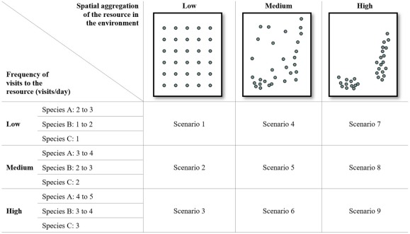

Since individual identification is not always possible in camera trapping (Caravaggi et al., 2017), we only considered interspecific interactions. To calculate the total number of interactions among all simulated animals, an interaction was recorded when at least two individuals were 10 m apart or less, either at the same time for direct interactions or within a 48-hour temporal window for indirect interactions.

#### 2.1.1. Quantifying interactions by GPS telemetry

To quantify interactions using GPS telemetry, we simulated marking 10 randomly selected animals of each species. We considered six efforts in GPS location recording (see Table 3). The random sampling was repeated 10 times for each scenario and effort, totaling 540 databases of marked individuals (9 scenarios, 6 efforts, and 10 repetitions). An interaction was considered to occur under the same criteria as previously for the overall individuals.

Table 3. Location recording interval (fix interval) set in GPS and number of cameras placed for camera trapping in regular grid (CT-RG) and for camera trapping for resource monitoring (CT-RM) in each sampling effort.

| Effort | GPS Fix interval | CT-RG No. Cameras (Grid spacing) | CT-RM No. Cameras (% of resource locations) |
| --- | --- | --- | --- |
| 1 | 4 h | 6 (2.6 km) | 5 (17 %) |
| 2 | 2 h | 12 (1.8 km) | 10 (33 %) |
| 3 | 1 h | 15 (1.6 km) | 15 (50 %) |
| 4 | 30 min. | 20 (1.4 km) | 20 (67 %) |
| 5 | 15 min. | 24 (1.3 km) | 25 (83 %) |
| 6 | 10 min. | 35 (1 km) | 30 (100 %) |

#### 2.1.2. Quantifying interactions by camera trapping

We considered the placement of cameras on a regular grid (CT-RG), the placement of cameras monitoring randomly selected resource locations (CT-RM), and the combination of both approaches. We considered six efforts in terms of the number of cameras (see Table 3) and repeated the sampling 10 times for each sampling effort and scenario, totaling 540 image databases for each approach. We considered a simulated animal to be captured by a [camera trap](https://www.sciencedirect.com/topics/agricultural-and-biological-sciences/camera-trap) when its trajectory intersected a square buffer of 5 m around each camera location, resulting in a detection area of 100 m<sup>2</sup> for each camera (Palencia et al., 2021b). Since we are working under the assumption of no possible individual identification, we established a threshold of two time steps (10 min) for the time that must elapse between two images of individuals of the same species to be considered distinct detections (Kukielka et al., 2013). An interaction was considered to occur when two individuals were detected by the same camera, being direct if detected at the same time and indirect if detected within a 48-hour time window.

#### 2.1.3. Comparison of performance among approaches

The detected interactions were summarized in a single database. For each of the 9 scenarios, 4 approaches (GPS, CT-RG, CT-RM, and the two camera trapping approaches combined), 6 sampling efforts, and 10 repetitions, the number of direct and indirect interactions was calculated for each of the 6 possible interspecific pairs: A-B, A-C, B-A, B-C, C-A, C-B, totaling 12,960 records. The species before the hyphen represents the one which visits the location where the interaction occurs first (depositor), and the one after the hyphen represents the one which visits it later (acquirer). These approaches only sample a part of the population (GPS) or the territory (CT-RG and CT-RM), so the real number of interactions in the entire population and territory is unknown unless extrapolations are made (Bohm et al., 2009, Yang et al., 2023). However, the number of detected interactions can indeed be considered as a predictor of the total number of interactions that actually occur (Triguero-Ocaña et al., 2020b). Consequently, we assessed the performance in detecting and quantifying animal interactions of the four approaches by modeling the real number of interactions between each pair of species, assuming it to follow a [Poisson distribution](https://www.sciencedirect.com/topics/agricultural-and-biological-sciences/poisson-distribution), and using the number of detected interactions for each pair of species as predictor. We performed the modeling independently for direct and indirect interactions, for each approach and for each sampling effort, totaling 48 models (4 approaches times 6 efforts, both for direct and indirect interactions). The goodness of fit of the model, measured by the R<sup>2</sup>, indicates how well the proportion of detected interactions between each species pair fits the one that actually takes place. The reason for following this procedure is that one method may detect more interactions than another, but fails to detect the proportion of interactions between each pair of species, thus failing to identify those species that may play a greater role in the spread of the disease. In addition, the number of missing pairs (i.e., the number of interacting pairs of species in which no interaction was detected) was also calculated for each approach and sampling effort.

#### 2.1.4. Factors influencing performance

The frequency with which animals need to visit the resource, as well as the spatial aggregation of the resource in the environment, are factors that can influence the performance of the approaches. This is because CT-RM only captures events at the resource, and CT-RG only captures events in certain locations that do not include the resource (except if, by chance, some cameras in the grid coincide with the resource). To analyze their effect on the performance of each approach, the total number of detected interactions was modeled, assuming that it follows a negative [binomial distribution](https://www.sciencedirect.com/topics/agricultural-and-biological-sciences/binomial-distribution) (given the overdispersion of the data; Zuur et al., 2009) using approach, sampling effort, resource visit frequency, and spatial aggregation of the resource in the environment as predictors. The latter three were considered as ordered factors since their values follow a non-linear progression. The inclusion of these factors allows us to control the number of detected interactions that would be expected if the relationship between the approach and the other factors were constant. Therefore, the interactions of the approach with the sampling effort, resource visit frequency, and resource aggregation were also included, aiming to determine if they are related differently to each method. Direct and indirect interactions were modeled separately.

### 2.2. Estimation of interactions with camera traps under field conditions

#### 2.2.1. Study area

The field study was carried out in an area within the Doñana National Park (DNP) in southwestern Spain (37°09′ N, 6°09′ W), a UNESCO Biosphere Reserve of 542.52 km<sup>2</sup>. The DNP is known for its remarkable biodiversity and comprises different habitats such as seasonal marshland in the eastern part, scrublands in the western part, and [sand dunes](https://www.sciencedirect.com/topics/agricultural-and-biological-sciences/dune) in the south. Within the park, there are three wild ungulate species: red deer (*Cervus elaphus*), [fallow deer](https://www.sciencedirect.com/topics/agricultural-and-biological-sciences/fallow-deer) (*Dama dama*), and [wild boar](https://www.sciencedirect.com/topics/agricultural-and-biological-sciences/wild-boars) (*[Sus scrofa](https://www.sciencedirect.com/topics/agricultural-and-biological-sciences/sus-scrofa)*), and several wild carnivores, such as [red fox](https://www.sciencedirect.com/topics/agricultural-and-biological-sciences/vulpes-vulpes) (*Vulpes vulpes*), [European badger](https://www.sciencedirect.com/topics/agricultural-and-biological-sciences/meles-meles) (*Meles meles*), Egyptian mongoose (*[Herpestes](https://www.sciencedirect.com/topics/agricultural-and-biological-sciences/herpestes)* *ichneumon*), genet (*Genetta genetta*), wildcat (*[Felis](https://www.sciencedirect.com/topics/agricultural-and-biological-sciences/felis)* *silvestris*) and [Iberian lynx](https://www.sciencedirect.com/topics/agricultural-and-biological-sciences/lynx-pardinus) (*Lynx pardinus*). The park is also home to extensively managed horses and to a native breed of cattle known as ‘marismeña’, which is also raised under extensive conditions throughout the year, except for periodic veterinary inspections. DNP's southwestern border is adjacent to the Atlantic Ocean, resulting in a dry subhumid [Mediterranean climate](https://www.sciencedirect.com/topics/agricultural-and-biological-sciences/mediterranean-climate) with Atlantic influences with a markedly irregular [water supply](https://www.sciencedirect.com/topics/agricultural-and-biological-sciences/water-supply), which shapes the dynamics of the marshland, leading to seasonal flooding in winter and spring, attracting ungulates to the scrub areas. In the [dry season](https://www.sciencedirect.com/topics/agricultural-and-biological-sciences/dry-season) of summer and fall, water sources and meadows become crucial habitats, drawing several species (Barasona et al., 2014a).

#### 2.2.2. Camera trapping

A total of 39 camera traps (Browning Recon Force 4 K Edge) were placed during a period of 104 days between the end of August and mid-December of 2020. The cameras were set to operate all day, recording a burst of four images at each activation, with the minimum triggering interval between activations. They were mounted on metal stakes at a height of 40 to 50 cm above the ground, facing north, and without bait. Of these, 24 cameras were placed on a regular grid with approximately 1 km spacing (CT-RG) and 15 cameras were placed monitoring water sources (CT-RM). During the summer and fall in DNP, water scarcity makes it mainly available in small artificial ponds built for [livestock](https://www.sciencedirect.com/topics/agricultural-and-biological-sciences/farm-animal), which can be easily monitored with a single camera, either because the camera's range covers the entire pond or because the entryway to the pond can be monitored. All camera traps were checked every three weeks to change batteries and memory cards.

#### 2.2.3. Quantifying interactions

The number of individuals captured in each image was not counted, considering the group as the epidemiological unit. As with the criterion used in the simulation, we considered consecutive images of the same species with less than 10 min between them as a single detection. A direct interaction between two groups was considered to occur when they were captured by the same camera simultaneously, and an indirect interaction when they were captured in the same camera within a 48-hour temporal window. Birds and small mammals were not considered. Additionally, species that appeared for fewer than 15 distinct days in the images were excluded from the analysis with the aim of avoiding the detection of pairs that involved those species that temporarily passed through the study area, such as the Iberian lynx or the wildcat.

#### 2.2.4. Comparing results

To analyze the differences in results obtained through CT-RG and CT-RM in DNP, we compared: (1) the number of species pairs in which interactions were detected, both direct and indirect; (2) the average number of interactions detected by each camera throughout the study period, and (3) how pairs of interacting species are ordered and how they are grouped based on the number of interactions. For the grouping, we used Agglomerative Hierarchical Clustering with a cluster linkage based on minimum within-cluster variance (known as Ward linkage; Murtagh and Contreras, 2017). When determining the cutting height of the tree (i.e., the difference between two groups at which it is decided that they belong to two distinct clusters), it is essential to consider that using a single value for two trees (in this case, CT-RG and CT-RM) based on a non-standardized value, such as the number of interactions, may result in the tree with lower values forming a reduced number of clusters. For this reason, we chose a height of 0.5 times the standard deviation of the detected interactions to compensate for the magnitude of the difference between approaches (Nielsen, 2016). A sensitivity analysis was carried out on the cutting height of the tree by testing 20 heights ranging from 0.05 to 1 time the standard deviation, at 0.05 intervals. The ratio of the number of clusters obtained in both trees (CT-RG and CT-RM) was extracted for each cutting height.

## 3. Results

### 3.1. Performance evaluation using simulations

#### 3.1.1. Comparison of performance among approaches

CT-RM resulted as the most reliable method to detect direct interspecific interactions between animals. It exhibited the highest R<sup>2</sup> and rarely missed a species pair (see Fig. 2). GPS showed low capabilities in terms of detecting direct interactions at low sampling efforts, missing several pairs of species. However, at high sampling efforts, it successfully identified all interacting pairs in most cases, resulting also in improved accuracy when quantifying differences among species pairs. On the other hand, CT-RG did not detect direct interactions in most cases, demonstrating poor capabilities for this purpose.

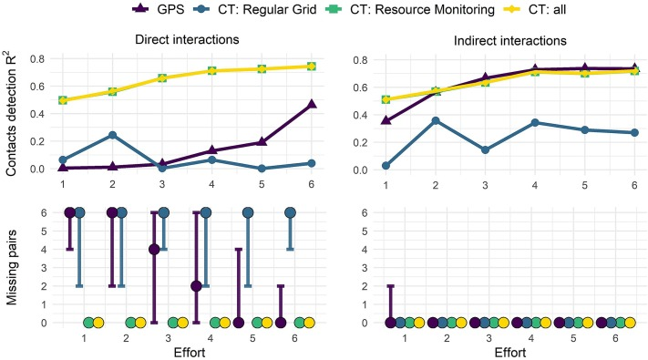

1. [Download: Download high-res image (393KB)](https://ars.els-cdn.com/content/image/1-s2.0-S1470160X24003340-gr2_lrg.jpg)
2. [Download: Download full-size image](https://ars.els-cdn.com/content/image/1-s2.0-S1470160X24003340-gr2.jpg)

Fig. 2. Goodness of fit (R<sup>2</sup>) of detected interactions to the total interactions that occurred in the simulation (top) and number of species pairs in which no interaction is detected (bottom; the circle represents the median and the bars represent the range) for [GPS](https://www.sciencedirect.com/topics/agricultural-and-biological-sciences/global-positioning-system) and camera trapping (CT) at each sampling effort. Both for direct (left) and indirect interactions (right).

All approaches detected all pairs of interacting species in most cases when identifying indirect interactions (see Fig. 2). However, the accuracy in quantifying differences among species pairs varied among the approaches: while GPS and CT-RM exhibited high R<sup>2</sup> values, CT-RG showed low values, which means a poor assessment of differences in the number of interactions among species pairs.

#### 3.1.2. Factors influencing performance

The modeling revealed that an increase in the spatial aggregation of the resource in the environment improved the performance of GPS and CT-RG to a greater extent than the performance of CT-RM (see Table 4 and Fig. 3) in the detection of both direct and indirect interactions. However, the increase in the frequency of animal visits to the resource had a much more marked positive effect on the performance of CT-RM than on the other approaches used. Finally, GPS is the method that benefits the most from the increase in the sampling effort. CT-RG, on the other hand, sees only a slight improvement in its performance as a consequence of higher sampling efforts.

Table 4. Predictors included in the model for the detection of direct (left) and indirect (right) interactions. The values shown for the predictors included as ordered factors correspond to the linear relation. The reference category for the values shown is GPS. Abbreviations: Regular Grid Camera Trapping (CT-RG), Resource Monitoring Camera Trapping (CT-RM), and both combined (CT-All), spatial aggregation of the resource in the environment (Aggr.), frequency of animal visits to the resource (Freq.), and sampling effort (Effort).

| Empty Cell Predictor | Direct interactions Estimate | Direct interactions Std. Error | Direct interactions p-value | Indirect interactions Estimate | Indirect interactions Std. Error | Indirect interactions p-value |
| --- | --- | --- | --- | --- | --- | --- |
| Approach |  |  |  |  |  |  |
| *CT-RG* | −1.855 | 0.104 | < 0.001 | −1.244 | 0.010 | < 0.001 |
| *CT-RM* | 4.508 | 0.074 | < 0.001 | 5.128 | 0.009 | < 0.001 |
| *CT-All* | 4.511 | 0.074 | < 0.001 | 5.130 | 0.009 | < 0.001 |
| Aggr. | 0.356 | 0.021 | < 0.001 | 0.403 | 0.011 | < 0.001 |
| Freq. | 0.560 | 0.021 | < 0.001 | 0.594 | 0.011 | < 0.001 |
| Effort | 5.586 | 0.025 | < 0.001 | 5.270 | 0.019 | < 0.001 |
| CT-RG * Aggr. | −0.198 | 0.108 | 0.067 | 0.406 | 0.016 | < 0.001 |
| CT-RM * Aggr. | −0.273 | 0.021 | < 0.001 | −0.296 | 0.015 | < 0.001 |
| CT-All * Aggr. | −0.274 | 0.021 | < 0.001 | −0.294 | 0.015 | < 0.001 |
| CT-RG * Freq. | 0.155 | 0.132 | 0.241 | −0.167 | 0.016 | < 0.001 |
| CT-RM * Freq. | 0.541 | 0.022 | < 0.001 | 0.558 | 0.015 | < 0.001 |
| CT-All * Freq. | 0.540 | 0.022 | < 0.001 | 0.556 | 0.015 | < 0.001 |
| CT-RG * Effort | −5.321 | 0.311 | < 0.001 | −4.550 | 0.025 | < 0.001 |
| CT-RM * Effort | −4.151 | 0.250 | < 0.001 | −3.840 | 0.023 | < 0.001 |
| CT-All * Effort | −4.153 | 0.250 | < 0.001 | −3.841 | 0.023 | < 0.001 |

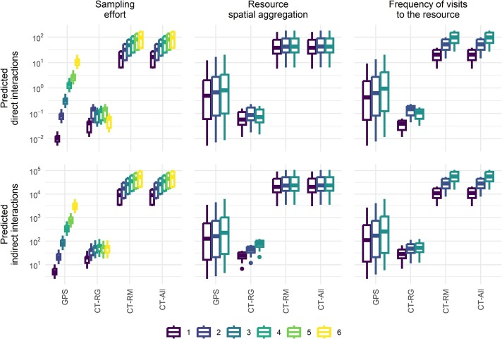

1. [Download: Download high-res image (377KB)](https://ars.els-cdn.com/content/image/1-s2.0-S1470160X24003340-gr3_lrg.jpg)
2. [Download: Download full-size image](https://ars.els-cdn.com/content/image/1-s2.0-S1470160X24003340-gr3.jpg)

Fig. 3. Interaction plot between the approach employed (GPS; regular grid camera trapping, CT-RG; resource monitoring, CT-RM; and both camera trapping approaches combined, CT-All) and the sampling effort (left), the spatial aggregation of the resource in the environment (in the middle), and the frequency of animal visits to the resource (right). The y-axes are on logarithmic scale.

### 3.2. Estimating interactions with camera traps using real data

Eight species were finally considered to quantify interactions in DNP: [European badger](https://www.sciencedirect.com/topics/agricultural-and-biological-sciences/meles-meles), cattle, [fallow deer](https://www.sciencedirect.com/topics/agricultural-and-biological-sciences/fallow-deer), horse, Egyptian mongoose, red deer, [red fox](https://www.sciencedirect.com/topics/agricultural-and-biological-sciences/vulpes-vulpes), and [wild boar](https://www.sciencedirect.com/topics/agricultural-and-biological-sciences/wild-boars), totaling 56 pairs of species when considering interactions in both directions. All pairs were detected interacting indirectly by CT-RM, and only two pairs (badger - mongoose and fallow deer – badger) remained undetected by the CT-RG (see Fig. 4). Forty pairs were also detected interacting directly by CT-RM, but only half of them were detected by CT-RG.

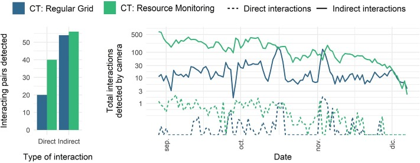

1. [Download: Download high-res image (312KB)](https://ars.els-cdn.com/content/image/1-s2.0-S1470160X24003340-gr4_lrg.jpg)
2. [Download: Download full-size image](https://ars.els-cdn.com/content/image/1-s2.0-S1470160X24003340-gr4.jpg)

Fig. 4. Number of pairs whose interaction has been detected through camera trapping (CT) in Doñana National Park (left) and temporal pattern of the number of interactions detected per camera (right; y-axis is on logarithmic scale), both for regular grid camera trapping and for resource monitoring camera trapping.

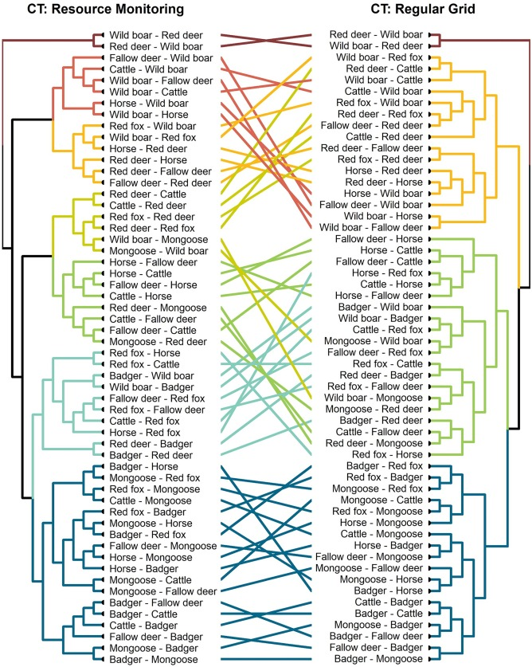

1. [Download: Download high-res image (1MB)](https://ars.els-cdn.com/content/image/1-s2.0-S1470160X24003340-gr5_lrg.jpg)
2. [Download: Download full-size image](https://ars.els-cdn.com/content/image/1-s2.0-S1470160X24003340-gr5.jpg)

Fig. 5. Tanglegram of clustering analyses of the total number of interactions detected per species pair in Doñana National Park by each camera trapping (CT) method. Species pairs are sorted from the highest number of interactions (top) to the lowest (bottom). The colors represent the clusters formed using a cutting height of 0.5 times the standard deviation of the number of interactions. Lines connect the location of the same species pair in both approaches.

## 4. Discussion

In both study scenarios (modelled and real data), monitoring resources through camera trapping (CT-RM) proved to be the most reliable method for detecting direct interactions. Furthermore, its performance in detecting indirect interactions is on par with GPS, which could be considered a reference in such studies (Triguero-Ocaña et al., 2021). However, the applicability of CT-RM depends on the environmental conditions and ecology of the species studied (mainly to the availability and distribution of a valuable resource for the species which can be monitored by camera trapping), being GPS less sensitive to these conditions. CT-RG proved to be a valid method for detecting which species interact indirectly, but it fails to quantify these interactions, calling for caution when identifying the species with the highest potential for disease transmission.

### 4.1. On the simulation

The results vary significantly when detecting direct or indirect interactions. CT-RM was the most effective method to detect direct interactions. Even with the lowest sampling efforts, it rarely fails to detect one of the interacting pairs of species (see Fig. 2). On the other hand, CT-RG is barely able to detect direct interactions, even with the highest sampling efforts. Camera trapping has temporal continuity, but lacks spatial continuity, so the location of the cameras is key for its performance. GPS shows low performance in the detection of direct interactions when the fix interval is wide. In fact, at the lowest sampling efforts, it may even fail to detect any. This is because direct interactions in the simulation, as in reality, are usually of short duration (Bohm et al., 2009, Cowie et al., 2015, Lavelle et al., 2016). GPS has spatial continuity, as the individual is sampled regardless of its location, but not temporal continuity, as locations are not continuously recorded. With the reduction of the GPS fix interval, the performance of GPS in detecting direct interactions increases exponentially. However, it is important to consider that a reduced fix interval implies higher battery consumption, which may lead to shorter sampling durations or the use of more expensive and/or heavier devices (Hebblewhite and Haydon, 2010, Shimada et al., 2020).

When it comes to detecting indirect interactions, the picture changes, especially in the detection of pairs of interacting species. All approaches, regardless of the sampling effort, show high performance for this purpose, rarely failing to detect any pair. This is particularly interesting in the case of CT-RG, as it is used in many wildlife-related studies (Rovero et al., 2013), and the already generated information can also be used to identify which species interact indirectly (Barroso et al., 2023, Triguero-Ocaña et al., 2020;b). However, its accuracy in quantifying the interactions is poor. On the other hand, GPS and CT-RM show similar performance for this purpose, and much higher than that shown by CT-RG. It is worth noting that the combination of CT-RG and CT-RM appears to provide no added value compared to the information obtained through CT-RM alone, both for direct and indirect interactions. However, the combination of both approaches could help to detect interactions involving species that do not use the monitored resource.

The spatial aggregation of the resource in the environment and the frequency with which individuals visit it should also be considered in the study design. An increase in the visit frequency (for instance, to water in summer) enhances the performance of CT-RM compared to the other approaches evaluated, as expected, since a higher number of visits result in a greater number of interactions at the resource, and these are detected by this method. However, the spatial aggregation of the resource favors GPS and CT-RG performance over CT-RM, probably because, with the resource being more aggregated, animals move in a more constrained, making them more likely to interact outside the resource, and such interaction can be detected by CT-RG or GPS but not by CT-RM. Therefore, in areas where the resource is spatially aggregated and animals visit it infrequently, such as water sources in wet areas (Varela-Castro et al., 2021), GPS may have an advantage over CT-RM. In contrast, in arid areas where water points are scarce and dispersed (Barasona et al., 2014a, Carrasco-Garcia et al., 2015), using CT-RM might be more advantageous. Combining CT-RM with GPS telemetry would be an effective alternative in all scenarios, as it provides complete monitoring of the individuals both at the resource and elsewhere. However, this option comes with high economic and effort costs.

### 4.2. On the real data

The results obtained from real camera trapping data in DNP support those obtained through the simulation. CT-RM shows greater ability than CT-RG to detect pairs of species interacting directly (see Fig. 4). However, there are minimal differences in the detection of pairs of species when the interaction occurs indirectly. Regarding the quantification of interactions, CT-RM reveals a decline in the number of interactions from late August to December, which had also been previously detected in DNP using GPS (Triguero-Ocaña et al., 2020a), but it seems undetectable by CT-RG. However, in the temporal pattern of interactions detected by CT-RG, two peaks are observed, corresponding to the weeks when park rangers conducted ungulate population controls (the authors, unpublished data). These controls involve shooting, which can increase animal activity and daily ranges and consequently the likelihood of detection by CT-RG (Laguna et al., 2021a, Laguna et al., 2021b, Picardi et al., 2018). The approaches also diverge when quantifying which pairs of species interact more frequently (see Fig. 5). Under the same clustering criterion, CT-RM forms a larger number of clusters than CT-RG, which signifies a higher resolution in distinguishing between groups of pairs of species according to the number of interactions. Moreover, the order of species pairs based on the total number of interactions differs between approaches, consistent with the simulation results, which had suggested greater reliability for the rankings obtained through CT-RM. Contemporary GPS data for DNP is not available, preventing a direct comparison. Although the results obtained through CT-RM and CT-RG differ from those in previous studies by GPS, the intra- and inter-annual variability in these patterns discourages their comparison (Triguero-Ocaña et al., 2020;a, Triguero-Ocaña et al., 2020;b).

The field application of the CT-RM method reveals additional limitations. In some cases, it is easy to know the location of the resources and monitor them or their access points, such as feeders or artificial water points on farms (Bacigalupo et al., 2022, Campbell et al., 2019, Kukielka et al., 2013, Payne et al., 2016, Varela-Castro et al., 2021). In the case of DNP, the scarcity of water and the presence of artificial ponds for its supplementation make resource monitoring easy (Barasona et al., 2014b). However, studies that exclusively focus on wildlife and/or extensively managed livestock, located in areas with abundant resources or where they are large (such as lakes, meadows, or rivers; e.g. Woodroffe et al., 2016), pose a challenge in identifying and monitoring the key resources, since the detectability area of a camera trap is reduced (Palencia et al., 2021b). Identifying the limiting resource is also crucial. In a wetland, for example, water may not be a limiting resource, but perhaps bedding areas could be. Therefore, when applying CT-RM, it is essential to carefully study which resource to monitor based on the ecology of the species and on the environment in which it is located. Failure to identify the limiting resource would lead to loss of performance. Where there is no limiting resource, GPS and CT-RG should improve their performance compared to CT-RM. Another limitation of CT-RM is the huge amount of images collected, as animals visit resources much more frequently than the random points monitored by regular grid. In this specific case, the 15 cameras monitoring resources over 104 days resulted in more than 1 million images. Processing such large quantities of images is time-consuming, although significant progress is being made in the field of artificial intelligence for automatic image processing (Green et al., 2020, Vélez et al., 2022). However, being a population-based method has certain advantages for camera trapping compared to GPS, which is individual-based. Camera trapping allows us to identify interactions among all species and individuals present in the study area, not just among those we have marked. In addition, GPS requires information about the population, as we will detect more interactions between the species that we mark more individuals of, but these may not be the most abundant in the study area (Triguero-Ocaña et al., 2020a), and marked individuals may not be representative of the population, leading to a failure in identifying the species that interact the most (Gilbertson et al., 2021, He et al., 2022).

### 4.3. Final remarks

The results, under our simulated and real scenarios for the considered range of sampling efforts, suggest CT-RM as the most reliable method to study the epidemiology of diseases primarily transmitted through direct contact, such as the sarcoptic mange, the [African Swine Fever](https://www.sciencedirect.com/topics/agricultural-and-biological-sciences/african-swine-fever), or the Chronic Wasting Disease studies in certain regions (Escobar et al., 2022, Potapov et al., 2016, Sanchez-Vizcaino et al., 2012). Nevertheless, GPS telemetry when using a reduced fix interval could also work for this purpose. For [epidemiological studies](https://www.sciencedirect.com/topics/agricultural-and-biological-sciences/epidemiological-study) on diseases transmitted through indirect interaction, like bovine tuberculosis (Broughan et al., 2016, Walter et al., 2012), both GPS and CT-RM seem to be effective approaches. The choice between one or the other will depend on the budget, the target species (size, detectability, capture feasibility, etc.) and the ability to identify and monitor key resources for animals through camera trapping. The combination of GPS and CT-RM is likely the most effective option for studying animal interactions, but it also involves a high cost in terms of financial resources and effort. On the other hand, CT-RG would be discouraged for epidemiological studies, although data from studies with other purposes can be used to detect pairs of species that may interact.

## CRediT authorship contribution statement

**Cesar Herraiz:** Conceptualization, Data curation, Formal analysis, Investigation, Methodology, Validation, Visualization, Writing – original draft, Writing – review & editing. **David Ferrer-Ferrando:** Investigation, Writing – review & editing. **Joaquín Vicente:** Funding acquisition, Project administration, Writing – review & editing. **Pelayo Acevedo:** Conceptualization, Funding acquisition, Methodology, Project administration, Supervision, Validation, Writing – original draft, Writing – review & editing.

## Declaration of competing interest

The authors declare that they have no known competing financial interests or personal relationships that could have appeared to influence the work reported in this paper.

## Acknowledgements

The present work has benefited from the financial aid of research grants funded by MICIN (PID2019-111699RB-I00). CH and DF-F would like to thank the European Social Fund (ESF), the regional Government of Castilla-La Mancha region (JCCM) and the University of Castilla-La Mancha (UCLM) for funding support through contracts SUPLY/19/180501/000487 and 2020-PREDUCLM-16022 respectively.

## Appendix A. Supplementary data

[What’s this?](https://service.elsevier.com/app/answers/detail/a_id/19286/supporthub/sciencedirect/)

The following are the Supplementary data to this article:[Download: Download zip file (3KB)](https://ars.els-cdn.com/content/image/1-s2.0-S1470160X24003340-mmc1.zip)

Supplementary data 1.

[Download: Download zip file (2KB)](https://ars.els-cdn.com/content/image/1-s2.0-S1470160X24003340-mmc2.zip)

Supplementary data 2.

[Download: Download zip file (8KB)](https://ars.els-cdn.com/content/image/1-s2.0-S1470160X24003340-mmc3.zip)

Supplementary data 3.

## Data availability

The data and code that support the findings of this study are openly available in Zenodo at http://doi.org/10.5281/zenodo.10605831.

## References

1. Bacigalupo et al., 2020

   S.A. Bacigalupo, L.K. Dixon, S. Gubbins, A.J. Kucharski, J.A. Drewe

   Towards a unified generic framework to define and observe contacts between livestock and wildlife: a systematic review

   PeerJ, 8 (2020), p. e10221, 10.7717/peerj.10221

   [View at publisher](https://doi.org/10.7717/peerj.10221)Google Scholar
2. Bacigalupo et al., 2022

   S.A. Bacigalupo, L.K. Dixon, S. Gubbins, A.J. Kucharski, J.A. Drewe

   Wild boar visits to commercial pig farms in Southwest England: implications for disease transmission

   Eur. J. Wildl. Res., 68 (2022), p. 69, 10.1007/s10344-022-01618-2

   View at publisher

   [View in Scopus](https://www.scopus.com/inward/record.url?eid=2-s2.0-85139419315&partnerID=10&rel=R3.0.0)Google Scholar
3. Barasona et al., 2014a

   J.A. Barasona, M.C. Latham, P. Acevedo, J.A. Armenteros, A.D. Latham, C. Gortazar, *et al.*

   Spatiotemporal interactions between wild boar and cattle: implications for cross-species disease transmission

   Vet. Res., 45 (2014), p. 122, 10.1186/s13567-014-0122-7

   View at publisher

   [View in Scopus](https://www.scopus.com/inward/record.url?eid=2-s2.0-84937978567&partnerID=10&rel=R3.0.0)Google Scholar
4. Barasona et al., 2014b

   J.A. Barasona, M. Mulero-Pazmany, P. Acevedo, J.J. Negro, M.J. Torres, C. Gortazar, *et al.*

   Unmanned aircraft systems for studying spatial abundance of ungulates: relevance to spatial epidemiology

   PLoS One, 9 (2014), p. e115608, 10.1371/journal.pone.0115608

   [View at publisher](https://doi.org/10.1371/journal.pone.0115608)Google Scholar
5. Barroso et al., 2023

   P. Barroso, D. Relimpio, J.A. Zearra, J.J. Ceron, P. Palencia, B. Cardoso, *et al.*

   Using integrated wildlife monitoring to prevent future pandemics through one health approach

   One Health, 16 (2023), Article 100479, 10.1016/j.onehlt.2022.100479

   [View PDF](https://www.sciencedirect.com/science/article/pii/S2352771422001112/pdfft?md5=77eecc8dba7f1dd9c6b28779d4d4ecda&pid=1-s2.0-S2352771422001112-main.pdf)[View article](https://www.sciencedirect.com/science/article/pii/S2352771422001112)[View in Scopus](https://www.scopus.com/inward/record.url?eid=2-s2.0-85145283024&partnerID=10&rel=R3.0.0)Google Scholar
6. Bassing et al., 2023

   S.B. Bassing, M. DeVivo, T.R. Ganz, B.N. Kertson, L.R. Prugh, T. Roussin, *et al.*

   Are we telling the same story? comparing inferences made from camera trap and telemetry data for wildlife monitoring

   Ecol. Appl., 33 (2023), p. e2745, 10.1002/eap.2745

   [View at publisher](https://ct.prod.getft.io/c2NpZW5jZWRpcmVjdF9jb250ZW50aG9zdGluZyx3aWxleSxodHRwczovL29ubGluZWxpYnJhcnkud2lsZXkuY29tL2RvaS9wZGYvMTAuMTAwMi9lYXAuMjc0NQ.0S18tJHuUQfQlZCviA-9wKJ1HXqOXZ2ZffelJaXTFZ8)

   [View in Scopus](https://www.scopus.com/inward/record.url?eid=2-s2.0-85142285696&partnerID=10&rel=R3.0.0)Google Scholar
7. Bohm et al., 2009

   M. Bohm, M.R. Hutchings, P.C. White

   Contact networks in a wildlife-livestock host community: identifying high-risk individuals in the transmission of bovine TB among badgers and cattle

   PLoS One, 4 (2009), p. e5016, 10.1371/journal.pone.0005016

   [View at publisher](https://doi.org/10.1371/journal.pone.0005016)[View in Scopus](https://www.scopus.com/inward/record.url?eid=2-s2.0-65549112109&partnerID=10&rel=R3.0.0)Google Scholar
8. Broughan et al., 2016

   J.M. Broughan, J. Judge, E. Ely, R.J. Delahay, G. Wilson, R.S. Clifton-Hadley, *et al.*

   A review of risk factors for bovine tuberculosis infection in cattle in the UK and Ireland

   Epidemiol. Infect., 144 (2016), pp. 2899-2926, 10.1017/S095026881600131X

   [View at publisher](https://doi.org/10.1017/S095026881600131X)[View in Scopus](https://www.scopus.com/inward/record.url?eid=2-s2.0-85018279320&partnerID=10&rel=R3.0.0)Google Scholar
9. Burton et al., 2015

   A.C. Burton, E. Neilson, D. Moreira, A. Ladle, R. Steenweg, J.T. Fisher, *et al.*

   REVIEW: wildlife camera trapping: a review and recommendations for linking surveys to ecological processes

   J. Appl. Ecol., 52 (2015), pp. 675-685, 10.1111/1365-2664.12432

   View at publisher

   [View in Scopus](https://www.scopus.com/inward/record.url?eid=2-s2.0-84929656572&partnerID=10&rel=R3.0.0)Google Scholar
10. Campbell et al., 2019

    E.L. Campbell, A.W. Byrne, F.D. Menzies, K.R. McBride, C.M. McCormick, M. Scantlebury, *et al.*

    Interspecific visitation of cattle and badgers to fomites: a transmission risk for bovine tuberculosis?

    Ecol. Evol., 9 (2019), pp. 8479-8489, 10.1002/ece3.5282

    [View at publisher](https://ct.prod.getft.io/c2NpZW5jZWRpcmVjdF9jb250ZW50aG9zdGluZyx3aWxleSxodHRwczovL29ubGluZWxpYnJhcnkud2lsZXkuY29tL2RvaS9lcGRmLzEwLjEwMDIvZWNlMy41MjgyP3NyYz1nZXRmdHI.t3FNHYpWNbm0CE3iJg_0NOfFRdWqQNK1cVofOWWCatI)

    [View in Scopus](https://www.scopus.com/inward/record.url?eid=2-s2.0-85070363669&partnerID=10&rel=R3.0.0)Google Scholar
11. Caravaggi et al., 2017

    A. Caravaggi, P.B. Banks, A.C. Burton, C.M.V. Finlay, P.M. Haswell, M.W. Hayward, *et al.*

    A review of camera trapping for conservation behaviour research

    Remote Sens. Ecol. Conserv., 3 (2017), pp. 109-122, 10.1002/rse2.48

    [View at publisher](https://ct.prod.getft.io/c2NpZW5jZWRpcmVjdF9jb250ZW50aG9zdGluZyx3aWxleSxodHRwczovL29ubGluZWxpYnJhcnkud2lsZXkuY29tL2RvaS9lcGRmLzEwLjEwMDIvcnNlMi40OD9zcmM9Z2V0ZnRy.En6eDf4lr1JU4ztYHrv1Dg3Zh6UcrKKA5mrX2uTkDE0)

    [View in Scopus](https://www.scopus.com/inward/record.url?eid=2-s2.0-85029390624&partnerID=10&rel=R3.0.0)Google Scholar
12. Carrasco-Garcia et al., 2015

    R. Carrasco-Garcia, J.A. Barasona, C. Gortazar, V. Montoro, J.M. Sanchez-Vizcaino, J. Vicente

    Wildlife and livestock use of extensive farm resources in south Central Spain: implications for disease transmission

    Eur. J. Wildl. Res., 62 (2015), pp. 65-78, 10.1007/s10344-015-0974-9

    [View at publisher](https://ct.prod.getft.io/c2NpZW5jZWRpcmVjdF9jb250ZW50aG9zdGluZyxzcHJpbmdlcixodHRwOi8vbGluay5zcHJpbmdlci5jb20vY29udGVudC9wZGYvMTAuMTAwNy9zMTAzNDQtMDE1LTA5NzQtOS5wZGY.RJ7TTy-5WA9olSl1HAJSSbXfhyigTigarmc5KbozNww)

    Google Scholar
13. Cowie et al., 2015

    C.E. Cowie, M.R. Hutchings, J.A. Barasona, C. Gortázar, J. Vicente, P.C.L. White

    Interactions between four species in a complex wildlife: livestock disease community: implications for Mycobacterium bovis maintenance and transmission

    Eur. J. Wildl. Res., 62 (2015), pp. 51-64, 10.1007/s10344-015-0973-x

    View at publisher

    Google Scholar
14. Craft, 2015

    M.E. Craft

    Infectious disease transmission and contact networks in wildlife and livestock

    Philos. Trans. R. Soc. Lond. B Biol. Sci., 370 (2015), 10.1098/rstb.2014.0107

    View at publisher

    [Google Scholar](https://scholar.google.com/scholar_lookup?title=Infectious%20disease%20transmission%20and%20contact%20networks%20in%20wildlife%20and%20livestock&publication_year=2015&author=M.E.%20Craft)
15. Delisle et al., 2021

    Z.J. Delisle, E.A. Flaherty, M.R. Nobbe, C.M. Wzientek, R.K. Swihart

    Next-generation camera trapping: systematic review of historic trends suggests keys to expanded research applications in ecology and conservation

    Front. Ecol. Evol., 9 (2021), 10.3389/fevo.2021.617996

    [View at publisher](https://doi.org/10.3389/fevo.2021.617996)Google Scholar
16. Drewe et al., 2012

    J.A. Drewe, N. Weber, S.P. Carter, S. Bearhop, X.A. Harrison, S.R. Dall, *et al.*

    Performance of proximity loggers in recording intra- and inter-species interactions: a laboratory and field-based validation study

    PLoS One, 7 (2012), p. e39068, 10.1371/journal.pone.0039068

    [View at publisher](https://doi.org/10.1371/journal.pone.0039068)[View in Scopus](https://www.scopus.com/inward/record.url?eid=2-s2.0-84862743136&partnerID=10&rel=R3.0.0)Google Scholar
17. Escobar et al., 2022

    L.E. Escobar, S. Carver, P.C. Cross, L. Rossi, E.S. Almberg, M.J. Yabsley, *et al.*

    Sarcoptic mange: an emerging panzootic in wildlife

    Transbound. Emerg. Dis., 69 (2022), pp. 927-942, 10.1111/tbed.14082

    [View at publisher](https://ct.prod.getft.io/c2NpZW5jZWRpcmVjdF9jb250ZW50aG9zdGluZyx3aWxleSxodHRwczovL29ubGluZWxpYnJhcnkud2lsZXkuY29tL2RvaS9wZGYvMTAuMTExMS90YmVkLjE0MDgy.V-bke1hkf8oGPO_83jdL8N4QTIZxvfxBauFK16zP8K4)

    [View in Scopus](https://www.scopus.com/inward/record.url?eid=2-s2.0-85105016423&partnerID=10&rel=R3.0.0)Google Scholar
18. Ferreira et al., 2023

    E.M. Ferreira, E.L. Duarte, M.V. Cunha, A. Mira, S.M. Santos

    Disentangling wildlife–cattle interactions in multi-host tuberculosis scenarios: systematic review and meta-analysis

    Mammal Rev. (2023), 10.1111/mam.12324

    [View at publisher](https://ct.prod.getft.io/c2NpZW5jZWRpcmVjdF9jb250ZW50aG9zdGluZyx3aWxleSxodHRwczovL29ubGluZWxpYnJhcnkud2lsZXkuY29tL2RvaS9wZGYvMTAuMTExMS9tYW0uMTIzMjQ.9N1JZq4jRfISz9ID8-rGK4HJ8TjBOZhHtPBfkZu5vko)

    Google Scholar
19. Ferrer-Ferrando et al., 2023

    D. Ferrer-Ferrando, J. Fernandez-Lopez, R. Triguero-Ocana, P. Palencia, J. Vicente, P. Acevedo

    The method matters. a comparative study of biologging and camera traps as data sources with which to describe wildlife habitat selection

    Sci. Total Environ., 902 (2023), Article 166053, 10.1016/j.scitotenv.2023.166053

    [View PDF](https://www.sciencedirect.com/science/article/pii/S0048969723046788/pdfft?md5=9307bb57dde618210b245d60dccf150f&pid=1-s2.0-S0048969723046788-main.pdf)[View article](https://www.sciencedirect.com/science/article/pii/S0048969723046788)[View in Scopus](https://www.scopus.com/inward/record.url?eid=2-s2.0-85167433226&partnerID=10&rel=R3.0.0)Google Scholar
20. Gilbertson et al., 2021

    M.L.J. Gilbertson, L.A. White, M.E. Craft

    Trade-offs with telemetry-derived contact networks for infectious disease studies in wildlife

    Methods Ecol. Evol., 12 (2021), pp. 76-87, 10.1111/2041-210x.13355

    View at publisher

    [View in Scopus](https://www.scopus.com/inward/record.url?eid=2-s2.0-85099011120&partnerID=10&rel=R3.0.0)Google Scholar
21. Green et al., 2020

    S.E. Green, J.P. Rees, P.A. Stephens, R.A. Hill, A.J. Giordano

    Innovations in camera trapping technology and approaches: the integration of citizen science and artificial intelligence

    Animals, 10 (2020), 10.3390/ani10010132

    [View at publisher](https://doi.org/10.3390/ani10010132)Google Scholar
22. Green et al., 2022

    S.E. Green, P.A. Stephens, M.J. Whittingham, R.A. Hill, M. Rowcliffe, R. Sollmann

    Camera trapping with photos and videos: implications for ecology and citizen science

    Remote Sens. Ecol. Conserv., 9 (2022), pp. 268-283, 10.1002/rse2.309

    [View at publisher](https://ct.prod.getft.io/c2NpZW5jZWRpcmVjdF9jb250ZW50aG9zdGluZyx3aWxleSxodHRwczovL29ubGluZWxpYnJhcnkud2lsZXkuY29tL2RvaS9lcGRmLzEwLjEwMDIvcnNlMi4zMDk_c3JjPWdldGZ0cg.vb5YmU7jeqrj4oOsyTcjYPacEQEEjBhyeBBClSHIifE)

    Google Scholar
23. Gurarie et al., 2015

    E. Gurarie, C. Bracis, M. Delgado, T.D. Meckley, I. Kojola, C.M. Wagner, *et al.*

    What is the animal doing? tools for exploring behavioural structure in animal movements

    J. Anim. Ecol., 85 (2015), pp. 69-84, 10.1111/1365-2656.12379

    View at publisher

    Google Scholar
24. He et al., 2022

    P. He, J.A. Klarevas-Irby, D. Papageorgiou, C. Christensen, E.D. Strauss, D.R. Farine

    A guide to sampling design for GPS-based studies of animal societies

    Methods Ecol. Evol. (2022), 10.1111/2041-210x.13999

    View at publisher

    Google Scholar
25. Hebblewhite and Haydon, 2010

    M. Hebblewhite, D.T. Haydon

    Distinguishing technology from biology: a critical review of the use of GPS telemetry data in ecology

    Philos. Trans. R. Soc. Lond. B Biol. Sci., 365 (2010), pp. 2303-2312, 10.1098/rstb.2010.0087

    View at publisher

    [View in Scopus](https://www.scopus.com/inward/record.url?eid=2-s2.0-77955185664&partnerID=10&rel=R3.0.0)Google Scholar
26. Hooten et al., 2019

    M.B. Hooten, H.R. Scharf, J.M. Morales

    Running on empty: recharge dynamics from animal movement data

    Ecol. Lett., 22 (2019), pp. 377-389, 10.1111/ele.13198

    View at publisher

    [View in Scopus](https://www.scopus.com/inward/record.url?eid=2-s2.0-85058116941&partnerID=10&rel=R3.0.0)Google Scholar
27. Hsing et al., 2022

    P.Y. Hsing, R.A. Hill, G.C. Smith, S. Bradley, S.E. Green, V.T. Kent, *et al.*

    Large-scale mammal monitoring: the potential of a citizen science camera-trapping project in the United Kingdom

    Ecological Solutions and Evidence, 3 (2022), 10.1002/2688-8319.12180

    View at publisher

    Google Scholar
28. Kukielka et al., 2013

    E. Kukielka, J.A. Barasona, C.E. Cowie, J.A. Drewe, C. Gortazar, I. Cotarelo, *et al.*

    Spatial and temporal interactions between livestock and wildlife in south Central Spain assessed by camera traps

    Prev. Vet. Med., 112 (2013), pp. 213-221, 10.1016/j.prevetmed.2013.08.008

    [View PDF](https://www.sciencedirect.com/science/article/pii/S0167587713002730/pdfft?md5=4f8e53efbd5e8ec16174e2ad1bd4d0df&pid=1-s2.0-S0167587713002730-main.pdf)[View article](https://www.sciencedirect.com/science/article/pii/S0167587713002730)[View in Scopus](https://www.scopus.com/inward/record.url?eid=2-s2.0-84886782022&partnerID=10&rel=R3.0.0)Google Scholar
29. Laguna et al., 2021a

    E. Laguna, J.A. Barasona, J. Vicente, O. Keuling, P. Acevedo

    Differences in wild boar spatial behaviour among land uses and management scenarios in Mediterranean ecosystems

    Sci. Total Environ., 796 (2021), Article 148966, 10.1016/j.scitotenv.2021.148966

    [View PDF](https://www.sciencedirect.com/science/article/pii/S0048969721040389/pdfft?md5=47cf2dc913cabea7f2551f60340d4076&pid=1-s2.0-S0048969721040389-main.pdf)[View article](https://www.sciencedirect.com/science/article/pii/S0048969721040389)[View in Scopus](https://www.scopus.com/inward/record.url?eid=2-s2.0-85109634843&partnerID=10&rel=R3.0.0)Google Scholar
30. Laguna et al., 2021b

    E. Laguna, A.J. Carpio, J. Vicente, J.A. Barasona, R. Triguero-Ocana, S. Jimenez-Ruiz, *et al.*

    The spatial ecology of red deer under different land use and management scenarios: protected areas, mixed farms and fenced hunting estates

    Sci. Total Environ., 786 (2021), Article 147124, 10.1016/j.scitotenv.2021.147124

    [View PDF](https://www.sciencedirect.com/science/article/pii/S004896972102194X/pdfft?md5=0345006d29f45554bd00be0194e9c21e&pid=1-s2.0-S004896972102194X-main.pdf)[View article](https://www.sciencedirect.com/science/article/pii/S004896972102194X)[View in Scopus](https://www.scopus.com/inward/record.url?eid=2-s2.0-85105268315&partnerID=10&rel=R3.0.0)Google Scholar
31. Latham et al., 2011

    A.D.M. Latham, M.C. Latham, N.A. McCutchen, S. Boutin

    Invading white-tailed deer change wolf–caribou dynamics in northeastern Alberta

    J. Wildl. Manag., 75 (2011), pp. 204-212, 10.1002/jwmg.28

    [View at publisher](https://ct.prod.getft.io/c2NpZW5jZWRpcmVjdF9jb250ZW50aG9zdGluZyx3aWxleSxodHRwczovL2FwaS53aWxleS5jb20vb25saW5lbGlicmFyeS90ZG0vdjEvYXJ0aWNsZXMvMTAuMTAwMiUyRmp3bWcuMjg.rg68IwgePlGxqjuyfteH5yVEz_QbCWZPDKrFHbpEOyg)

    [View in Scopus](https://www.scopus.com/inward/record.url?eid=2-s2.0-79951895167&partnerID=10&rel=R3.0.0)Google Scholar
32. Lavelle et al., 2016

    M.J. Lavelle, S.L. Kay, K.M. Pepin, D.A. Grear, H. Campa 3rd, K.C. VerCauteren

    Evaluating wildlife-cattle contact rates to improve the understanding of dynamics of bovine tuberculosis transmission in Michigan, USA

    Prev. Vet. Med., 135 (2016), pp. 28-36, 10.1016/j.prevetmed.2016.10.009

    [View PDF](https://www.sciencedirect.com/science/article/pii/S0167587716303130/pdfft?md5=c6bb520ea43cf8c356db737111e03c9d&pid=1-s2.0-S0167587716303130-main.pdf)[View article](https://www.sciencedirect.com/science/article/pii/S0167587716303130)[View in Scopus](https://www.scopus.com/inward/record.url?eid=2-s2.0-84994210568&partnerID=10&rel=R3.0.0)Google Scholar
33. Manlove et al., 2022

    K. Manlove, M. Wilber, L. White, G. Bastille-Rousseau, A. Yang, M.L.J. Gilbertson, *et al.*

    Defining an epidemiological landscape that connects movement ecology to pathogen transmission and pace-of-life

    Ecol. Lett. (2022), 10.1111/ele.14032

    [View at publisher](https://ct.prod.getft.io/c2NpZW5jZWRpcmVjdF9jb250ZW50aG9zdGluZyx3aWxleSxodHRwczovL29ubGluZWxpYnJhcnkud2lsZXkuY29tL2RvaS9wZGYvMTAuMTExMS9lbGUuMTQwMzI.8O48HEjSUv7ISI3CjHXoFogjdc7dJSRzJyJ60U3ALRA)

    Google Scholar
34. Mejia Salazar et al., 2016

    M.F. Mejia Salazar, C. Waldner, J. Stookey, T.K. Bollinger

    Infectious disease and grouping patterns in mule deer

    PLoS One, 11 (2016), p. e0150830, 10.1371/journal.pone.0150830

    [View at publisher](https://doi.org/10.1371/journal.pone.0150830)Google Scholar
35. Mueller and Fagan, 2008

    T. Mueller, W.F. Fagan

    Search and navigation in dynamic environments – from individual behaviors to population distributions

    Oikos, 117 (2008), pp. 654-664, 10.1111/j.0030-1299.2008.16291.x

    View at publisher

    [View in Scopus](https://www.scopus.com/inward/record.url?eid=2-s2.0-42949143519&partnerID=10&rel=R3.0.0)Google Scholar
36. Murtagh and Contreras, 2017

    F. Murtagh, P. Contreras

    Algorithms for hierarchical clustering: an overview, II

    Wiley Interdisciplinary Reviews: Data Mining and Knowledge Discovery, 7 (2017), p. e1219

    [View in Scopus](https://www.scopus.com/inward/record.url?eid=2-s2.0-85028764537&partnerID=10&rel=R3.0.0)[Google Scholar](https://scholar.google.com/scholar_lookup?title=Algorithms%20for%20hierarchical%20clustering%3A%20an%20overview%2C%20II&publication_year=2017&author=F.%20Murtagh&author=P.%20Contreras)
37. Niedballa et al., 2019

    J. Niedballa, A. Wilting, R. Sollmann, H. Hofer, A. Courtiol, M. Rowcliffe, *et al.*

    Assessing analytical methods for detecting spatiotemporal interactions between species from camera trapping data

    Remote Sens. Ecol. Conserv., 5 (2019), pp. 272-285, 10.1002/rse2.107

    [View at publisher](https://ct.prod.getft.io/c2NpZW5jZWRpcmVjdF9jb250ZW50aG9zdGluZyx3aWxleSxodHRwczovL29ubGluZWxpYnJhcnkud2lsZXkuY29tL2RvaS9lcGRmLzEwLjEwMDIvcnNlMi4xMDc_c3JjPWdldGZ0cg.qlbI2l7ZwuIeXPQ73sbhSznLgTmOovK0Wm6cNgy6PIA)

    [View in Scopus](https://www.scopus.com/inward/record.url?eid=2-s2.0-85073021478&partnerID=10&rel=R3.0.0)Google Scholar
38. Nielsen, 2016

    F. Nielsen

    Hierarchical clustering

    Introduction to HPC with MPI for Data Science (2016), pp. 195-211

    View at publisher

    [Crossref](https://doi.org/10.1007/978-3-319-21903-5_8)[Google Scholar](https://scholar.google.com/scholar_lookup?title=Hierarchical%20clustering&publication_year=2016&author=F.%20Nielsen)
39. Palencia et al., 2021a

    P. Palencia, J. Fernández-López, J. Vicente, P. Acevedo

    Innovations in movement and behavioural ecology from camera traps: day range as model parameter

    Methods Ecol. Evol., 12 (2021), pp. 1201-1212, 10.1111/2041-210x.13609

    [View at publisher](https://ct.prod.getft.io/c2NpZW5jZWRpcmVjdF9jb250ZW50aG9zdGluZyx3aWxleSxodHRwczovL29ubGluZWxpYnJhcnkud2lsZXkuY29tL2RvaS9wZGYvMTAuMTExMS8yMDQxLTIxMFguMTM2MDk.sqSd9OekZLCDHkzxWfLoaBdtYoAHfqmHgicTwZCcqj4)

    [View in Scopus](https://www.scopus.com/inward/record.url?eid=2-s2.0-85105175586&partnerID=10&rel=R3.0.0)Google Scholar
40. Palencia et al., 2021b

    P. Palencia, J. Vicente, R.C. Soriguer, P. Acevedo

    Towards a best-practices guide for camera trapping: assessing differences among camera trap models and settings under field conditions

    J. Zool., 316 (2021), pp. 197-208, 10.1111/jzo.12945

    [View at publisher](https://ct.prod.getft.io/c2NpZW5jZWRpcmVjdF9jb250ZW50aG9zdGluZyx3aWxleSxodHRwczovL29ubGluZWxpYnJhcnkud2lsZXkuY29tL2RvaS9lcGRmLzEwLjExMTEvanpvLjEyOTQ1P3NyYz1nZXRmdHI.yWlsAKMhFwmD69iqshV-rsz0KVQ16QhfxnmWGVc90uw)

    Google Scholar
41. Payne et al., 2016

    A. Payne, S. Philipon, J. Hars, B. Dufour, E. Gilot-Fromont

    Wildlife interactions on baited places and waterholes in a french area infected by bovine tuberculosis

    Front Vet Sci, 3 (2016), p. 122, 10.3389/fvets.2016.00122

    [View at publisher](https://doi.org/10.3389/fvets.2016.00122)Google Scholar
42. Phillips et al., 2019

    E.M. Phillips, J.K. Horne, J.E. Zamon, J.J. Felis, J. Adams

    Does perspective matter? a case study comparing eulerian and lagrangian estimates of common murre (Uria aalge) distributions

    Ecol. Evol., 9 (2019), pp. 4805-4819, 10.1002/ece3.5083

    [View at publisher](https://ct.prod.getft.io/c2NpZW5jZWRpcmVjdF9jb250ZW50aG9zdGluZyx3aWxleSxodHRwczovL29ubGluZWxpYnJhcnkud2lsZXkuY29tL2RvaS9lcGRmLzEwLjEwMDIvZWNlMy41MDgzP3NyYz1nZXRmdHI.tiAcwVxSvEmBEWR91ONYBA_LbsPvKXfk0rJpA4lvAeQ)

    [View in Scopus](https://www.scopus.com/inward/record.url?eid=2-s2.0-85064830786&partnerID=10&rel=R3.0.0)Google Scholar
43. Picardi et al., 2018

    S. Picardi, M. Basille, W. Peters, J.M. Ponciano, L. Boitani, F. Cagnacci

    Movement responses of roe deer to hunting risk

    J. Wildl. Manag., 83 (2018), pp. 43-51, 10.1002/jwmg.21576

    View at publisher

    Google Scholar
44. Potapov et al., 2016

    A. Potapov, E. Merrill, M. Pybus, M.A. Lewis

    Chronic wasting disease: transmission mechanisms and the possibility of harvest management

    PLoS One, 11 (2016), p. e0151039, 10.1371/journal.pone.0151039

    [View at publisher](https://doi.org/10.1371/journal.pone.0151039)[View in Scopus](https://www.scopus.com/inward/record.url?eid=2-s2.0-84962497329&partnerID=10&rel=R3.0.0)Google Scholar
45. Rovero et al., 2013

    Rovero F, Zimmermann F, Berzi D, Meek P. “ Which camera trap type and how many do I need?” A review of camera features and study designs for a range of wildlife research applications. Hystrix 2013.

    Google Scholar
46. Rowcliffe et al., 2008

    J.M. Rowcliffe, J. Field, S.T. Turvey, C. Carbone

    Estimating animal density using camera traps without the need for individual recognition

    J. Appl. Ecol., 45 (2008), pp. 1228-1236

    View at publisher

    [Crossref](https://doi.org/10.1111/j.1365-2664.2008.01473.x)[View in Scopus](https://www.scopus.com/inward/record.url?eid=2-s2.0-46749145712&partnerID=10&rel=R3.0.0)Google Scholar
47. Sanchez-Vizcaino et al., 2012

    J.M. Sanchez-Vizcaino, L. Mur, B. Martinez-Lopez

    African swine fever: an epidemiological update

    Transbound. Emerg. Dis., 59 (Suppl 1) (2012), pp. 27-35, 10.1111/j.1865-1682.2011.01293.x

    View at publisher

    [View in Scopus](https://www.scopus.com/inward/record.url?eid=2-s2.0-84858282553&partnerID=10&rel=R3.0.0)[Google Scholar](https://scholar.google.com/scholar_lookup?title=African%20swine%20fever%3A%20an%20epidemiological%20update&publication_year=2012&author=J.M.%20Sanchez-Vizcaino&author=L.%20Mur&author=B.%20Martinez-Lopez)
48. Shimada et al., 2020

    T. Shimada, M. Thums, M. Hamann, C.J. Limpus, G.C. Hays, N.N. FitzSimmons, *et al.*

    Optimising sample sizes for animal distribution analysis using tracking data

    Methods Ecol. Evol., 12 (2020), pp. 288-297, 10.1111/2041-210x.13506

    [View at publisher](https://ct.prod.getft.io/c2NpZW5jZWRpcmVjdF9jb250ZW50aG9zdGluZyx3aWxleSxodHRwczovL29ubGluZWxpYnJhcnkud2lsZXkuY29tL2RvaS9wZGYvMTAuMTExMS8yMDQxLTIxMFguMTM1MDY.4lx0tGBs0N-dIHO3K1FOJzd2YnjZGoIzNE17Tnj2nXQ)

    Google Scholar
49. Smith et al., 2020

    J.A. Smith, J.P. Suraci, J.S. Hunter, K.M. Gaynor, C.B. Keller, M.S. Palmer, *et al.*

    Zooming in on mechanistic predator–prey ecology: integrating camera traps with experimental methods to reveal the drivers of ecological interactions

    J. Anim. Ecol., 89 (2020), pp. 1997-2012, 10.1111/1365-2656.13264

    View at publisher

    [View in Scopus](https://www.scopus.com/inward/record.url?eid=2-s2.0-85087209676&partnerID=10&rel=R3.0.0)Google Scholar
50. Spiegel et al., 2020

    O. Spiegel, P. Ward, G. Rotem, J.S. Gilchrist, J. Tichon, Z.Y. Jia

    Social interactions in striped hyena inferred from camera trap data: is it more social than previously thought?

    Curr. Zool., 66 (2020), pp. 345-353, 10.1093/cz/zoaa003

    View at publisher

    Google Scholar
51. Triguero-Ocaña et al., 2019

    R. Triguero-Ocaña, J. Vicente, P. Acevedo

    Performance of proximity loggers under controlled field conditions: an assessment from a wildlife ecological and epidemiological perspective. animal

    Biotelemetry (2019), p. 7, 10.1186/s40317-019-0186-2

    View at publisher

    Google Scholar
52. Triguero-Ocaña et al., 2020;a

    R. Triguero-Ocaña, B. Martinez-Lopez, J. Vicente, J.A. Barasona, J. Martinez-Guijosa, P. Acevedo

    Dynamic network of interactions in the wildlife-livestock Interface in Mediterranean Spain: an epidemiological point of view

    Pathogens (2020;), p. 9, 10.3390/pathogens9020120

    [View at publisher](https://doi.org/10.3390/pathogens9020120)Google Scholar
53. Triguero-Ocaña et al., 2020;b

    R. Triguero-Ocaña, J. Vicente, P. Palencia, E. Laguna, P. Acevedo

    Quantifying wildlife-livestock interactions and their spatio-temporal patterns: is regular grid camera trapping a suitable approach?

    Ecol. Ind. (2020;), p. 117, 10.1016/j.ecolind.2020.106565

    View at publisher

    Google Scholar
54. Triguero-Ocaña et al., 2021

    R. Triguero-Ocaña, J. Vicente, M.J. Lavelle, P. Acevedo

    Collecting data to assess the interactions between livestock and wildlife. Diseases at the Wildlife-Livestock Interface: Research and Perspectives in a Changing World

    Springer (2021), pp. 307-338

    View at publisher

    [Crossref](https://doi.org/10.1007/978-3-030-65365-1_10)Google Scholar
55. Varela-Castro et al., 2021

    L. Varela-Castro, I.A. Sevilla, A. Payne, E. Gilot-Fromont, M. Barral

    Interaction patterns between wildlife and cattle reveal opportunities for mycobacteria transmission in farms from north-eastern Atlantic Iberian Peninsula

    Animals (basel) (2021), p. 11, 10.3390/ani11082364

    [View at publisher](https://doi.org/10.3390/ani11082364)Google Scholar
56. Vélez et al., 2022

    J. Vélez, W. McShea, H. Shamon, P.J. Castiblanco-Camacho, M.A. Tabak, C. Chalmers, *et al.*

    An evaluation of platforms for processing camera-trap data using artificial intelligence

    Methods Ecol. Evol., 14 (2022), pp. 459-477, 10.1111/2041-210x.14044

    [View at publisher](https://ct.prod.getft.io/c2NpZW5jZWRpcmVjdF9jb250ZW50aG9zdGluZyx3aWxleSxodHRwczovL29ubGluZWxpYnJhcnkud2lsZXkuY29tL2RvaS9wZGYvMTAuMTExMS8yMDQxLTIxMFguMTQwNDQ.0yVDb3kqqOPCSvFLfjzRbHGA4LXGK7zinmfsrCD1rXo)

    Google Scholar
57. Walter et al., 2012

    W.D. Walter, C.W. Anderson, R. Smith, M. Vanderklok, J.J. Averill, K.C. Vercauteren

    On-farm mitigation of transmission of tuberculosis from white-tailed deer to cattle: literature review and recommendations

    Vet Med Int, 2012 (2012), Article 616318, 10.1155/2012/616318

    View at publisher

    [View in Scopus](https://www.scopus.com/inward/record.url?eid=2-s2.0-84867391564&partnerID=10&rel=R3.0.0)Google Scholar
58. Woodroffe et al., 2016

    R. Woodroffe, C.A. Donnelly, C. Ham, S.Y. Jackson, K. Moyes, K. Chapman, *et al.*

    Badgers prefer cattle pasture but avoid cattle: implications for bovine tuberculosis control

    Ecol. Lett., 19 (2016), pp. 1201-1208, 10.1111/ele.12654

    View at publisher

    [View in Scopus](https://www.scopus.com/inward/record.url?eid=2-s2.0-84991206680&partnerID=10&rel=R3.0.0)Google Scholar
59. Yang et al., 2023

    A. Yang, M.Q. Wilber, K.R. Manlove, R.S. Miller, R. Boughton, J. Beasley, *et al.*

    Deriving spatially explicit direct and indirect interaction networks from animal movement data

    Ecol. Evol., 13 (2023), p. e9774, 10.1002/ece3.9774

    Finding PDF…[View in Scopus](https://www.scopus.com/inward/record.url?eid=2-s2.0-85152684850&partnerID=10&rel=R3.0.0)Google Scholar
60. Zuur et al., 2009

    A.F. Zuur, E.N. Ieno, N.J. Walker, A.A. Saveliev, G.M. Smith

    Mixed Effects Models and Extensions in Ecology with R, Vol 574:, Springer (2009)

    Google Scholar

© 2024 The Authors. Published by Elsevier Ltd.